# R Reference Guide

Joyce Bor

12-08-2022

# R Reference Guide

## Loading Data and Packages

A package in R is a collection of pre-built functions. In order to install these packages, we use this function:

- install.packages(“packageName”)  
  After the package is installed, you call the packages using either of the following functions:
- library()
- require()  
  In our example, we we install our **palmerpenguins** data and load it to our directory:

```r
options(repos = list(CRAN="http://cran.rstudio.com/"))
#install package
install.packages("palmerpenguins")
#load package
library(palmerpenguins)
```

We call this “loading a package” in R.  
Note that you do not need to use quotes around the package name when loading a package.  
This package is designed to simplify tasks within an *RProject*. The function **here()** returns the absolute path to the base directory of your *RProject*.  
For this example, let us assume that:

- You are working on RStudio and have an RProject loaded.
- You have a subdirectory of your main RProject called *data*.
- In your data subfolder, there is a file called *.csv*.

This package most useful for opening and reading data. In this example, we will load the here package, and then read our ginkgo data, which is found in our *data* subfolder.

```r
library(here)
dat_ginkgo = read.csv(
  here("/Users/joycebor/Documents/environmental_data/data", "ginkgo_data_2022.csv")
  )
```

## Data Structures

A data structure is a format for organizing, processing, and storing data. In R, the basic data structures are:

- **Vectors**  
  A vector in R is the most basic type of object. It is a sequence of data elements of the same type.  
  To create a vector in R, we use the combine function **c()**.  
  Vector elements are separated by commas and placed in parentheses.  
  *Example*

```r
numeric_vector <- c(1, 2, 3)
character_vector <- c("x", "y", "z")
```

- **Lists**  
  A list in R allows you to gather a variety of objects under one name. Unlike in a vector or a matrix, these objects do not have to be of the same type. They can be matrices, vectors, data frames, or other lists. To create a list, we use the function **list()**.  
  *Example*

```r
#creating the list
list1 = list("a", 3, 372, "dog", "biscuits")
#calling the list
list1
```

```
## [[1]]
## [1] "a"
##
## [[2]]
## [1] 3
##
## [[3]]
## [1] 372
##
## [[4]]
## [1] "dog"
##
## [[5]]
## [1] "biscuits"
```

- To create a named list, we can use the following code:

```r
list2 = list(name1 = "a", name2 = "b")
```

- To name a list that has already been created:

```r
list2 = list("a", "b")
names(list2) = c("name1", "name2")
```

- length() can be used to find the length of a list or any data set in r as follows:

```r
length(list1)
```

```
## [1] 5
```

- **Matrices**  
  A matrix in R is a collection of elements of the same data type arranged in rows and columns.  
  To create a matrix in R, we use the **matrix()** function.  
  *Example*

```r
matrix(1:6, byrow = TRUE, nrow = 2)
```

```
##      [,1] [,2] [,3]
## [1,]    1    2    3
## [2,]    4    5    6
```

The first argument is the collection of elements in the matrix. Another way to write 1:6 is:  
c(1, 2, 3, 4, 5, 6)  
The second argument, *byrow*, tells R to fill the matrix by rows. To fill the matrix by columns, we use:  
byrow = FALSE  
The third argument, **nrow**, tells R to create a matrix with 2 rows.

- **Data frames**  
  A data frame in R has the variables of a dataset as columns and the observations as rows. In our example, we will use our ginkgo data frame. This file is found in the index.Rmd file, and we have downloaded it into our *data* subfolder.

```r
#reading ginkgo data
#make sure you are working in the right directory
require(here)
dat_ginkgo = read.csv(
  here("/Users/joycebor/Documents/environmental_data/data", "ginkgo_data_2022.csv")
  )
```

When working with a large dataset, it is important to have a clear understanding of its structure. The following functions are useful when doing this:  
- head()  
This shows the first observations of a data frame.  
- tail()  
This shows the last observations of the data frame.  
- str()  
This shows the structure of the dataset, e.g, the total number of observations, variables, the full list of variables, the data type of each variable, and the first observations.  
-nrow()  
This shows the number of rows in a dataset.  
-ncol()  
This shows the number of columns in a dataset.  
-dim()  
This is used to set of get the dimensions of a dataset.

```r
# summary of dataset
head(dat_ginkgo)
```

```
##   site_id seeds_present max_width max_depth notch_depth petiole_length
## 1     216         FALSE        85        59          12             91
## 2     216         FALSE        72        54           0             56
## 3     216         FALSE        64        42           0             71
## 4     216         FALSE        76        48           0             44
## 5     216         FALSE        85        50           5             40
## 6     216         FALSE        75        46           7             50
```

```r
tail(dat_ginkgo)
```

```
##     site_id seeds_present max_width max_depth notch_depth petiole_length
## 215   12982         FALSE       111        67          28             70
## 216   12982         FALSE        44        26           3             14
## 217   12982         FALSE       117        80          43             69
## 218   12982         FALSE        93        72          32            113
## 219   12982         FALSE       101        71          28            111
## 220   12982         FALSE       145       125          92             31
```

```r
str(dat_ginkgo)
```

```
## 'data.frame':    220 obs. of  6 variables:
##  $ site_id       : int  216 216 216 216 216 216 216 216 216 216 ...
##  $ seeds_present : logi  FALSE FALSE FALSE FALSE FALSE FALSE ...
##  $ max_width     : int  85 72 64 76 85 75 72 81 87 87 ...
##  $ max_depth     : int  59 54 42 48 50 46 60 60 56 54 ...
##  $ notch_depth   : num  12 0 0 0 5 7 2 0 3 9 ...
##  $ petiole_length: int  91 56 71 44 40 50 82 84 70 40 ...
```

```r
nrow(dat_ginkgo)
```

```
## [1] 220
```

```r
ncol(dat_ginkgo)
```

```
## [1] 6
```

```r
dim(dat_ginkgo)
```

```
## [1] 220   6
```

- **Factors**  
  A factor in R is used to store categorical variable. A categorical variable belongs to a limited number of categories, while a continuous variable can correspond to an infinite number of values. An example of a categorical variable is sex. Say you have a vector containing the sex of 3 different individuals. We use the function **factor()** on the vector to store the categorical variables or ‘factor levels’:

```r
#create vector
sex_vec = c("Male", "Female", "Male")
#convert into factor
factor_sex_vec = factor(sex_vec)
```

Sometimes, when working with a data set that contains factors with specific factor levels, we might want to change the names of these levels for clarity. We use the function **levels()** for this:

```r
#r vector
sex_vec = c("M", "F", "M")
# r factor
factor_sex_vec = factor(sex_vec)
#find levels
levels(factor_sex_vec)
```

```
## [1] "F" "M"
```

```r
#correctly assign the levels or R will assign them alphabetically. Correctly map "F" to "Female" and "M" to "Male".
levels(factor_sex_vec) = c("Female", "Male")
#calling the factor
factor_sex_vec
```

```
## [1] Male   Female Male
## Levels: Female Male
```

## Subsetting

Subsetting refers to selecting variables and observations from a data structure. There are 3 main methods to do this. We will use our ginkgo data to demonstrate them below.

- **By name**  
  To subset a data frame by name, we use the **$** as follows:

```r
#selecting the row in our ginkgo data with maximum widths.
dat_ginkgo$max_width
```

```
##   [1]  85  72  64  76  85  75  72  81  87  87  94  92  70  84  61 102  82  64
##  [19]  53  66  69  55  56  64  60  59  57  53  68  56  75  63  82  83  60  67
##  [37]  75  92 110  54  77  59  51 100  92  77  99  62  80  86  63  79  91  72
##  [55]  64  53  71  61  70  93  75  87  86  87  95  88  85  95  95  52  84  74
##  [73]  87  76  57  92  94  79  97  50 100  97  63  96  97  70  83  80  85 100
##  [91] 112 115  83 106  95  80 120  76  50  90  94  69  93  59  60 103  95  90
## [109]  80  90 106  98  73  89  65  83 116  90  86 104  92 103 100  91 102  99
## [127]  98 104  80  68  62  77  86  72  70  63  72  65  69  67  35  67  63  71
## [145]  77  60  70  69  55  72  84 106  61 114  95  86  60  78  86  91  79  95
## [163]  72 102  72 107  95  91  94  90  98  63  58  67  92  75  74  73  73  94
## [181]  76  86  78  74  89  77  80  71  69  81  39  60  50  47  52  61  56  45
## [199]  64  42 103  84 118 120 100 111 104  94  78  70  92  48  79  91 111  44
## [217] 117  93 101 145
```

- **By position** We use square brackets **[]** to select objects in a specific row and column respectively.

```r
#selecting the first row of ginkgo data
dat_ginkgo[1,]
```

```
##   site_id seeds_present max_width max_depth notch_depth petiole_length
## 1     216         FALSE        85        59          12             91
```

```r
#selecting the element in row 2 and column 3 of ginkgo data
dat_ginkgo[2,3]
```

```
## [1] 72
```

```r
#selecting the 3rd column of the gingko data
dat_ginkgo[,3]
```

```
##   [1]  85  72  64  76  85  75  72  81  87  87  94  92  70  84  61 102  82  64
##  [19]  53  66  69  55  56  64  60  59  57  53  68  56  75  63  82  83  60  67
##  [37]  75  92 110  54  77  59  51 100  92  77  99  62  80  86  63  79  91  72
##  [55]  64  53  71  61  70  93  75  87  86  87  95  88  85  95  95  52  84  74
##  [73]  87  76  57  92  94  79  97  50 100  97  63  96  97  70  83  80  85 100
##  [91] 112 115  83 106  95  80 120  76  50  90  94  69  93  59  60 103  95  90
## [109]  80  90 106  98  73  89  65  83 116  90  86 104  92 103 100  91 102  99
## [127]  98 104  80  68  62  77  86  72  70  63  72  65  69  67  35  67  63  71
## [145]  77  60  70  69  55  72  84 106  61 114  95  86  60  78  86  91  79  95
## [163]  72 102  72 107  95  91  94  90  98  63  58  67  92  75  74  73  73  94
## [181]  76  86  78  74  89  77  80  71  69  81  39  60  50  47  52  61  56  45
## [199]  64  42 103  84 118 120 100 111 104  94  78  70  92  48  79  91 111  44
## [217] 117  93 101 145
```

- **subset()** This function is used to select the object specified in the brackets. The arguments of this function include the object to be subsetted and a logical expression that indicates the elements or rows to keep. In this example, we are using the penguins data to select all the data associated with the Adelie species:

```r
options(repos = list(CRAN="http://cran.rstudio.com/"))
#install and load palmerpenguins data
install.packages("palmerpenguins")
require(palmerpenguins)
#subsetting Adelie species
subset(penguins, species == "Adelie")
```

```
## # A tibble: 152 × 8
##    species island    bill_length_mm bill_depth_mm flipper_length_mm body_mass_g
##    <fct>   <fct>              <dbl>         <dbl>             <int>       <int>
##  1 Adelie  Torgersen           39.1          18.7               181        3750
##  2 Adelie  Torgersen           39.5          17.4               186        3800
##  3 Adelie  Torgersen           40.3          18                 195        3250
##  4 Adelie  Torgersen           NA            NA                  NA          NA
##  5 Adelie  Torgersen           36.7          19.3               193        3450
##  6 Adelie  Torgersen           39.3          20.6               190        3650
##  7 Adelie  Torgersen           38.9          17.8               181        3625
##  8 Adelie  Torgersen           39.2          19.6               195        4675
##  9 Adelie  Torgersen           34.1          18.1               193        3475
## 10 Adelie  Torgersen           42            20.2               190        4250
## # … with 142 more rows, and 2 more variables: sex <fct>, year <int>
```

## Numerical Data Exploration

Numerical data exploration is important for getting a compact summary of data, including aspects sych as the mean, median, range, variance and standard deviation.  
*Example*

```r
#gives a summary of data in a dataset
summary(dat_ginkgo)
```

```
##     site_id      seeds_present     max_width        max_depth
##  Min.   :  216   Mode :logical   Min.   : 35.00   Min.   : 24.0
##  1st Qu.: 3470   FALSE:180       1st Qu.: 67.00   1st Qu.: 45.0
##  Median : 4874   TRUE :40        Median : 80.00   Median : 53.0
##  Mean   : 5726                   Mean   : 79.95   Mean   : 53.1
##  3rd Qu.: 6719                   3rd Qu.: 93.00   3rd Qu.: 60.0
##  Max.   :12982                   Max.   :145.00   Max.   :125.0
##   notch_depth     petiole_length
##  Min.   : 0.000   Min.   : 13.00
##  1st Qu.: 0.000   1st Qu.: 45.00
##  Median : 2.000   Median : 58.00
##  Mean   : 5.977   Mean   : 59.51
##  3rd Qu.: 6.250   3rd Qu.: 71.00
##  Max.   :92.000   Max.   :126.00
```

```r
#returns the mean of the maximum widths in ginkgo data
mean(na.omit(dat_ginkgo$max_width))
```

```
## [1] 79.95455
```

```r
#returns the standard deviation of the maximum depths in ginkgo data
sd(na.omit(dat_ginkgo$max_depth))
```

```
## [1] 12.7281
```

**na.omit()** removes all NA values from the data set we are performing the numerical methods.

## Graphical Data Exploration

This enables us to get visual or intuitive representation of the data using graphs/plots. We can create scatterplots, histograms and boxplots.

- **plot()**  
  This function creates a scatterplot using the following main arguments:  
  x, y: the x and y coordinates of the plot.  
  main: the main title of the plot.  
  xlab: a label for the x axis.  
  ylab: a label for the y axis.  
  xlim: the x limits of the plot.  
  ylim: the y limits of the plot.  
  col: the colors for lines and points.  
  pch: a vector of plotting symbols.  
  cex: a vector giving the scale of he plotting symbols.

We are going to create a scatterplot of maximum leaf depth (x) and maximum leaf width (y) using the ginkgo data:

```r
max(dat_ginkgo$max_width)
```

```
## [1] 145
```

```r
max(dat_ginkgo$max_depth)
```

```
## [1] 125
```

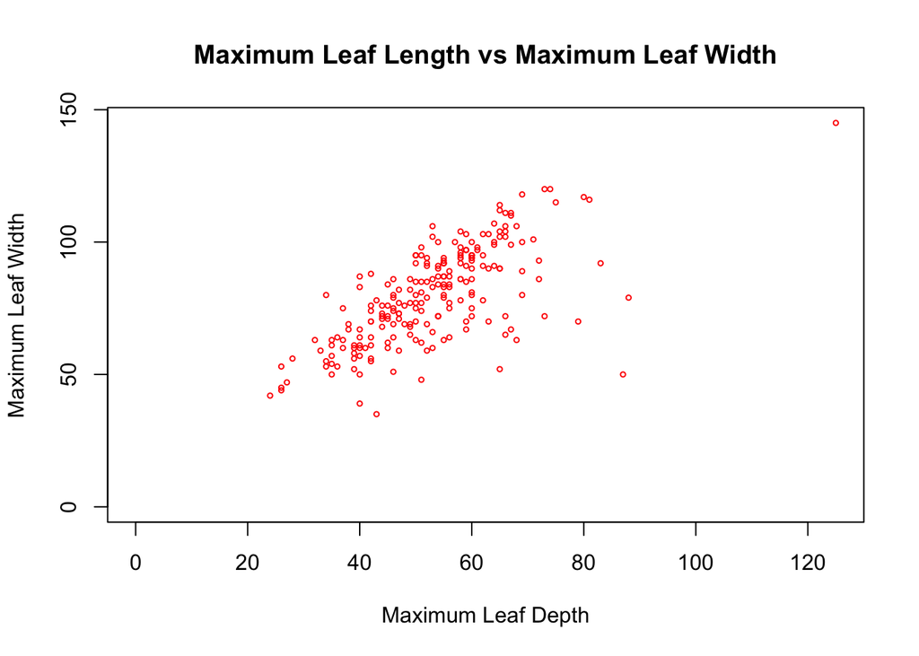

```r
#creating a scatterplot
plot(dat_ginkgo$max_depth, dat_ginkgo$max_width,
     main = "Maximum Leaf Length vs Maximum Leaf Width",
     xlab = "Maximum Leaf Depth",
     ylab = "Maximum Leaf Width",
     xlim = c(0, 125),
     ylim = c(0, 145),
     col = "red",
     pch = 1,
     cex = 0.5)
```

- **hist()** This function computes a histogram od the given data using the following main arguments:  
  x: a vector of values to be plotted on the histogram.  
  breaks: a vector giving breakpoints between histogram cells, a function to compute the vector, a single number giving the number of cells desired, a character string naming an algorithm to compute the number of cells, or a function to compute the number of cells.  
  We are going to create a histogram of the flipper lengths of the penguins.

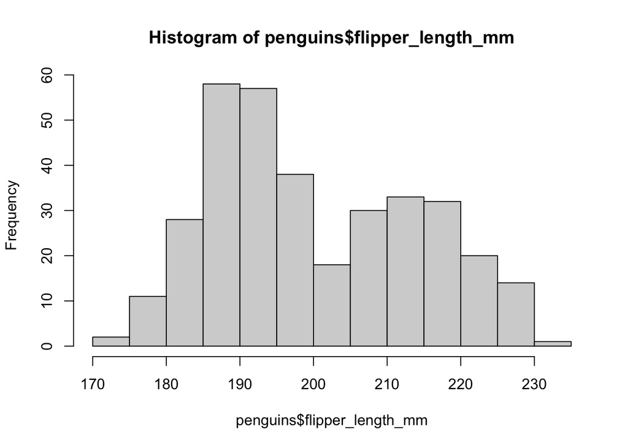

```r
#creating a histogram with 15 cells
hist(penguins$flipper_length_mm, breaks = 15)
```

* **boxplot()**  
Boxplots measure how well distributed data is in a data set.

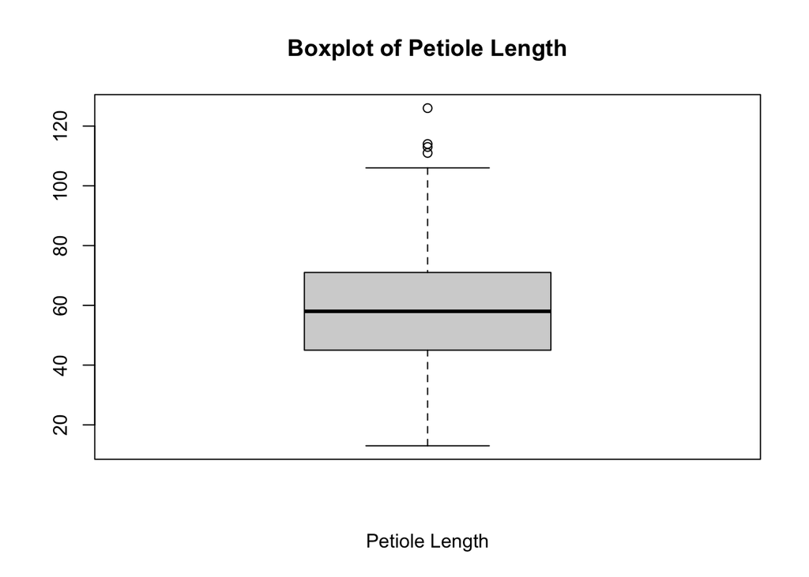

```r
#simple boxplot of ginkgo petiole lengths.
boxplot(dat_ginkgo$petiole_length,
        main = "Boxplot of Petiole Length",
        xlab = "Petiole Length")
```

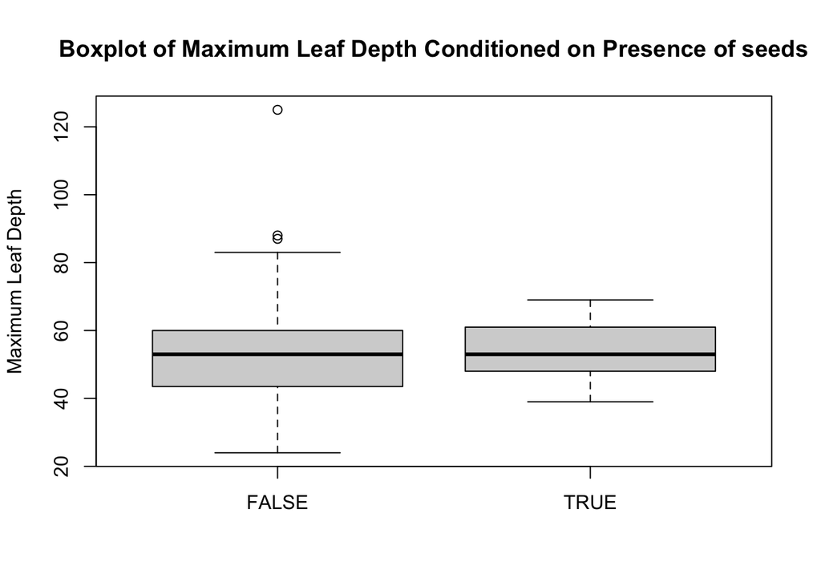

```r
#conditional boxplot of maximum depth conditioned on seeds present.
boxplot(dat_ginkgo$max_depth ~ dat_ginkgo$seeds_present,
        main = "Boxplot of Maximum Leaf Depth Conditioned on Presence of seeds",
        xlab = NULL,
        ylab = "Maximum Leaf Depth")
```

We can create a panel with multiple plots at the same time using **par()**. This function uses the argument **mfrow** to determine a vector with row and column values for the grid, as shown below:

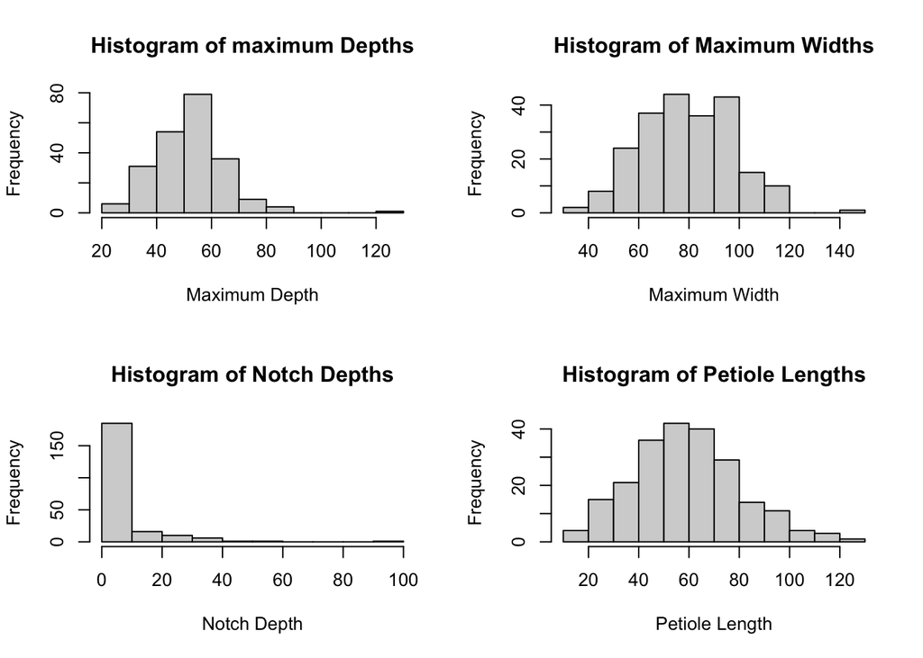

```r
#creating a 4-panel figure of histograms arranged in a 2 by 2 matrix from our ginkgo data.
par(mfrow = c(2, 2))
hist(dat_ginkgo$max_depth, main = "Histogram of maximum Depths", xlab = "Maximum Depth")
hist(dat_ginkgo$max_width, main = "Histogram of Maximum Widths", xlab = "Maximum Width")
hist(dat_ginkgo$notch_depth, main = "Histogram of Notch Depths", xlab = "Notch Depth")
hist(dat_ginkgo$petiole_length, main = "Histogram of Petiole Lengths", xlab = "Petiole Length")
```

## Distribution Functions

Distributions are tools for describing the likelihood of observing specific events from the set of all possible events. The main distributions used in data analysis are binomial, normal, and poisson distributions.  
A binomial has 2 parameters:  
- n: number of trials.  
- p: the probability of success in an individual trial.  
The following functions are used to generate binomial distributions in r:

- **dbinom()**  
  This function returns the value of the probability density function of the binomial distribution of a certain random variable. It has the following arguments:  
  x (the random variable)  
  size (the number of trials)  
  prob (the probability of success for each trial)  
  *Example*

```r
#find the probability of 8 successes during 16 trials, where the probability of success on each trial is 0.7
dbinom(x = 8, size = 16, prob = 0.7)
```

```
## [1] 0.04867802
```

- **pbinom()**  
  This function returns the value of the cumulative density function of the binomial distribution of a certain random variable. It has the same arguments as the dbinom() function. It returns the area to the left of a given value q in a binomial distribution. To find the area to the right instead, we use the argument: **lower.tail = FALSE**.

```r
# find the probability of more than 3 success in 6 trials, where the probability of success on each trial is 0.5
pbinom(q = 3, size = 6, prob = 0.5, lower.tail = FALSE)
```

```
## [1] 0.34375
```

- **qbinom()**  
  This function returns the value of the inverse cumulative density function of the binomial distribution of a random variable. It is used to find the quantile specified of the binomial distribution and has the same arguments as the pbinom() and dbinom().

```r
#find the 20th quantile of a binomial distribution with 50 trials, where the probability of success on each trial is 0.5
qbinom(0.20, size = 50, prob = 0.5)
```

```
## [1] 22
```

A normally distributed data set in R usually means that the data is from a random collection of independent sources. When plotted with the value of the variable on the x axis and the count of the values in the y axis, we observe a bell shape curve, the center of which corresponds to the mean of the data set. The following are used to generate normal distributions in R.

- **dnorm()**  
  This returns the value of the probability density function of a normal distribution. It has the following arguments:  
  x (the random variable)  
  mean (population mean)  
  sd (population standard deviation)

```r
#find the value of the standard normal distribution at x = 5, with mean set to 0 and standard deviation set to 1.
dnorm(x = 5, mean = 0, sd = 1)
```

```
## [1] 1.48672e-06
```

- **pnorm()**  
  This returns the value of the cumulative density function of the normal distribution of a random variable. It has the same arguments as dnorm(), and the following logical argument:  
  lower.tail = FALSE: this assumes the area to the right of the specified variable.

```r
#finding the percentage of plants that are taller than 6 inches when the mean of the heights of the plants is 4.5 inches and the standard deviation is 0.2 inches
pnorm(6, mean = 4.5, sd = 0.2, lower.tail = FALSE)
```

```
## [1] 3.190892e-14
```

- **rnorm()**  
  This generates a vector of normally distributed random variables with the following arguments:  
  n (vector length)  
  mean (vector of means)  
  sd (vector standard deviation)

```r
#generating a vector of 15 normally distributed random variables with a mean of 100 and standard deviation of 3.
rnorm(15, mean = 100, sd = 3)
```

```
##  [1] 100.10713 100.56526  98.48145  97.68901 101.06893 103.18733  98.67517
##  [8] 100.65113  98.74941  96.80317 104.27929 100.77156 103.11506 102.41767
## [15]  98.44738
```